## Heart Disease - Classifications By Kassem@elcaiseri

### Heart Disease - Classifications + Visualization

# 1. Introduction

This database contains 76 attributes, but all published experiments refer to using a subset of 14 of them. In particular, the Cleveland database is the only one that has been used by ML researchers to this date. The "goal" field refers to the presence of heart disease in the patient.

```python
import warnings
warnings.simplefilter("ignore")
```

# 2. Data Preparation

```python
import numpy as np # linear algebra
import pandas as pd # data processing, CSV file I/O (e.g. pd.read_csv)

import matplotlib.pyplot as plt
import seaborn as sns; sns.set()

# Input data files are available in the "../input/" directory.
# For example, running this (by clicking run or pressing Shift+Enter) will list the files in the input directory

import os
#print(os.listdir("../input"))

# Any results you write to the current directory are saved as output.
```

```python
df = pd.read_csv("./heart.csv")
```

```python
df.head()
```

|  | age | sex | cp | trestbps | chol | fbs | restecg | thalach | exang | oldpeak | slope | ca | thal | target |
| --- | --- | --- | --- | --- | --- | --- | --- | --- | --- | --- | --- | --- | --- | --- |
| 0 | 63 | 1 | 3 | 145 | 233 | 1 | 0 | 150 | 0 | 2.3 | 0 | 0 | 1 | 1 |
| 1 | 37 | 1 | 2 | 130 | 250 | 0 | 1 | 187 | 0 | 3.5 | 0 | 0 | 2 | 1 |
| 2 | 41 | 0 | 1 | 130 | 204 | 0 | 0 | 172 | 0 | 1.4 | 2 | 0 | 2 | 1 |
| 3 | 56 | 1 | 1 | 120 | 236 | 0 | 1 | 178 | 0 | 0.8 | 2 | 0 | 2 | 1 |
| 4 | 57 | 0 | 0 | 120 | 354 | 0 | 1 | 163 | 1 | 0.6 | 2 | 0 | 2 | 1 |

```python
df.info()
```

```
<class 'pandas.core.frame.DataFrame'>
RangeIndex: 303 entries, 0 to 302
Data columns (total 14 columns):
 #   Column    Non-Null Count  Dtype
---  ------    --------------  -----
 0   age       303 non-null    int64
 1   sex       303 non-null    int64
 2   cp        303 non-null    int64
 3   trestbps  303 non-null    int64
 4   chol      303 non-null    int64
 5   fbs       303 non-null    int64
 6   restecg   303 non-null    int64
 7   thalach   303 non-null    int64
 8   exang     303 non-null    int64
 9   oldpeak   303 non-null    float64
 10  slope     303 non-null    int64
 11  ca        303 non-null    int64
 12  thal      303 non-null    int64
 13  target    303 non-null    int64
dtypes: float64(1), int64(13)
memory usage: 33.3 KB
```

```python
# check for NAN values
df.isnull().sum()
```

```
age         0
sex         0
cp          0
trestbps    0
chol        0
fbs         0
restecg     0
thalach     0
exang       0
oldpeak     0
slope       0
ca          0
thal        0
target      0
dtype: int64
```

```python
# data size
df.shape
```

```
(303, 14)
```

```python
df.describe()
```

|  | age | sex | cp | trestbps | chol | fbs | restecg | thalach | exang | oldpeak | slope | ca | thal | target |
| --- | --- | --- | --- | --- | --- | --- | --- | --- | --- | --- | --- | --- | --- | --- |
| count | 303.000000 | 303.000000 | 303.000000 | 303.000000 | 303.000000 | 303.000000 | 303.000000 | 303.000000 | 303.000000 | 303.000000 | 303.000000 | 303.000000 | 303.000000 | 303.000000 |
| mean | 54.366337 | 0.683168 | 0.966997 | 131.623762 | 246.264026 | 0.148515 | 0.528053 | 149.646865 | 0.326733 | 1.039604 | 1.399340 | 0.729373 | 2.313531 | 0.544554 |
| std | 9.082101 | 0.466011 | 1.032052 | 17.538143 | 51.830751 | 0.356198 | 0.525860 | 22.905161 | 0.469794 | 1.161075 | 0.616226 | 1.022606 | 0.612277 | 0.498835 |
| min | 29.000000 | 0.000000 | 0.000000 | 94.000000 | 126.000000 | 0.000000 | 0.000000 | 71.000000 | 0.000000 | 0.000000 | 0.000000 | 0.000000 | 0.000000 | 0.000000 |
| 25% | 47.500000 | 0.000000 | 0.000000 | 120.000000 | 211.000000 | 0.000000 | 0.000000 | 133.500000 | 0.000000 | 0.000000 | 1.000000 | 0.000000 | 2.000000 | 0.000000 |
| 50% | 55.000000 | 1.000000 | 1.000000 | 130.000000 | 240.000000 | 0.000000 | 1.000000 | 153.000000 | 0.000000 | 0.800000 | 1.000000 | 0.000000 | 2.000000 | 1.000000 |
| 75% | 61.000000 | 1.000000 | 2.000000 | 140.000000 | 274.500000 | 0.000000 | 1.000000 | 166.000000 | 1.000000 | 1.600000 | 2.000000 | 1.000000 | 3.000000 | 1.000000 |
| max | 77.000000 | 1.000000 | 3.000000 | 200.000000 | 564.000000 | 1.000000 | 2.000000 | 202.000000 | 1.000000 | 6.200000 | 2.000000 | 4.000000 | 3.000000 | 1.000000 |

```python
# target distribution
df.target.value_counts()
```

```
1    165
0    138
Name: target, dtype: int64
```

# 3. Visualization

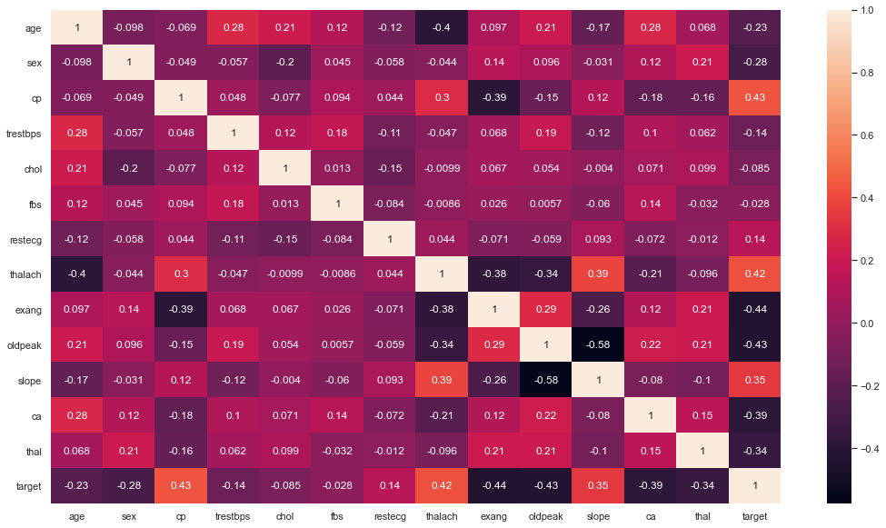

```python
# show correlation matrix
corr = df.corr()
plt.figure(figsize=(18,10))
sns.heatmap(corr, annot=True, )
plt.show()
```

According to the color bar, the lighter color between features, the more correlation (linear) they had.

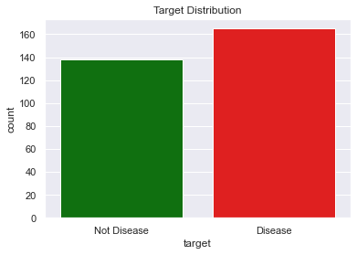

```python
# plot target dist.
sns.countplot(df.target, palette=['green', 'red'])
plt.xticks([0, 1], labels=['Not Disease', 'Disease'])
plt.title("Target Distribution");
```

The dataset is quite small, but the target proportion for patients who have disease are slightly more than who have not.

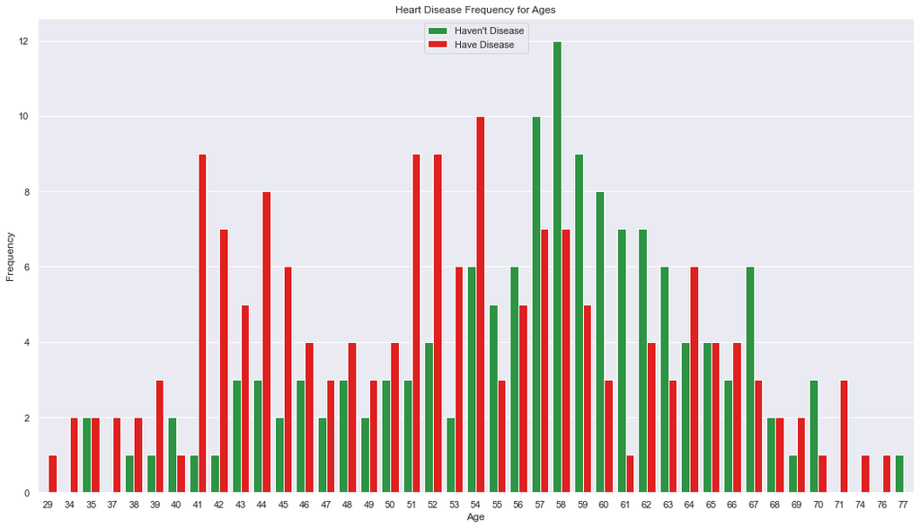

```python
plt.figure(figsize=(18, 10))
sns.countplot(x='age', hue='target', data=df, palette=['#1CA53B', 'red'])
plt.legend(["Haven't Disease", "Have Disease"])
plt.title('Heart Disease Frequency for Ages')
plt.xlabel('Age')
plt.ylabel('Frequency')
plt.show()
```

The disease rate is too high for age from 29~54 years old compare with whom in the same age, and this rate drop for people who older than 55 years old which quite interesting.

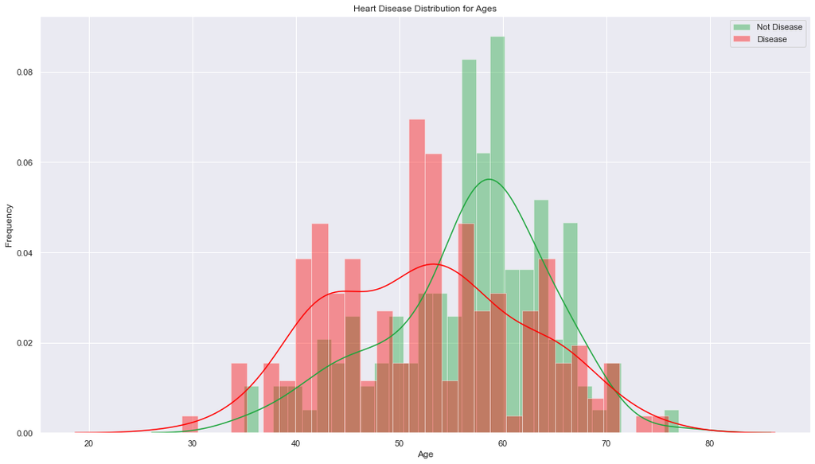

```python
#sns.set_style("whitegrid")
plt.figure(figsize=(18, 10))
sns.distplot(df.age[df['target'] == 0], bins=30, color='#1CA53B', label='Not Disease')
sns.distplot(df.age[df['target'] == 1], bins=30, color='red', label='Disease')
plt.legend()
plt.title('Heart Disease Distribution for Ages')
plt.xlabel('Age')
plt.ylabel('Frequency')
plt.show()
```

Here is another graph which prove what we said above.

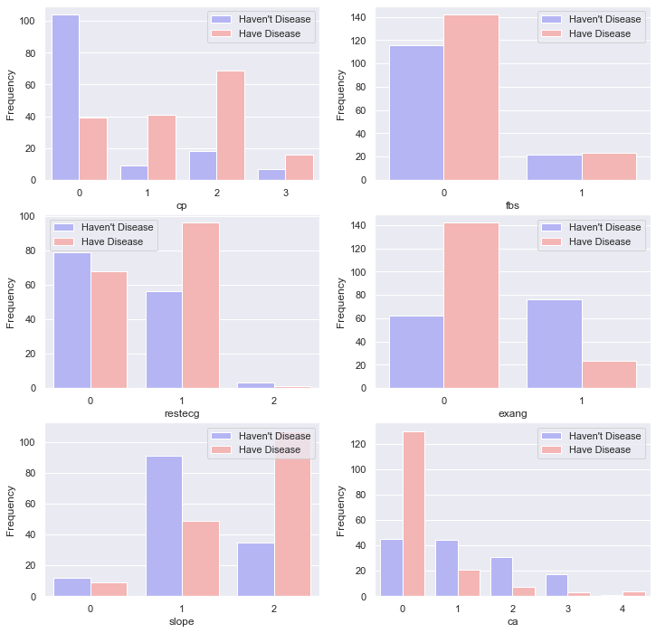

```python
fig, axes = plt.subplots(3, 2, figsize=(12,12))
fs = ['cp', 'fbs', 'restecg','exang', 'slope', 'ca']
for i, axi in enumerate(axes.flat):
    sns.countplot(x=fs[i], hue='target', data=df, palette='bwr', ax=axi)
    axi.set(ylabel='Frequency')
    axi.legend(["Haven't Disease", "Have Disease"])
```

some insight from figures:

1. people with (cp==0 and slope==1) are less likely to have disease.
2. people with (ca==0, slope==2 and exang==0) are more likely to have disease.

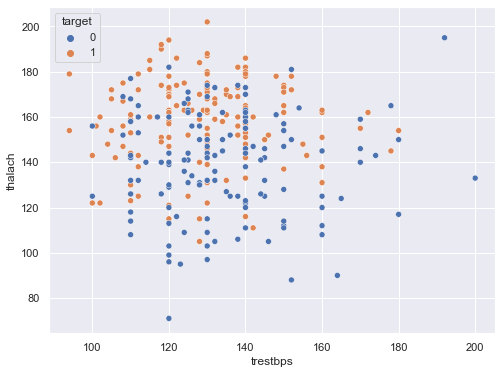

```python
plt.figure(figsize=(8,6))
sns.scatterplot(x='trestbps', y='thalach', data=df, hue='target')
plt.show()
```

Most of disease case exist on the upper left of trestbps vs thalach graph.

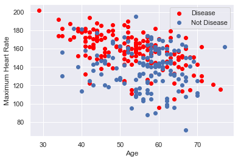

```python
plt.scatter(x=df.age[df.target==1], y=df.thalach[(df.target==1)], c="red")
plt.scatter(x=df.age[df.target==0], y=df.thalach[(df.target==0)])
plt.legend(["Disease", "Not Disease"])
plt.xlabel("Age")
plt.ylabel("Maximum Heart Rate")
plt.show()
```

# 4. Machine Learning

```python
from sklearn.preprocessing import StandardScaler

# Import tools
from sklearn.model_selection import train_test_split
from sklearn.model_selection import cross_val_score

from sklearn.metrics import accuracy_score, confusion_matrix, classification_report
from sklearn.metrics import roc_curve, auc

np.random.seed(42)
```

```python
# Define our feasures and leabels
X = df.drop(['target'], axis=1).values
y = df['target'].values
```

```python
# normalize for training
scale = StandardScaler()
X = scale.fit_transform(X)
```

YOU HAVE TO DO THE NORMALIZEING PART AFTER SPLITTING YOUR DATA TO AVOID **DATA LEAKAGES.**

```python
class Model:
    """
    Machine Learning model class contains all necessary features.

    Attributes:
    model: sklearn model object
    X: Features
    y: target

    Return:
    Trained model

    """
    def __init__(self, model, X, y):
        self.model = model
        self.X = X
        self.y = y
        self.X_train, self.X_test, self.y_train, self.y_test = train_test_split(self.X, self.y, test_size=0.2, random_state=42)

        self.model.fit(self.X_train, self.y_train)
        print(f"{self.model_str()} Model Trained..")
        self.y_pred = self.model.predict(self.X_test)

    def model_str(self):
        """Model name"""
        return str(self.model.__class__.__name__)

    def crossValScore(self, cv=5):
        """cross Val Score"""
        print(self.model_str() + "\n" + "="*60)
        scores = ["accuracy", "precision", "recall", "roc_auc"]
        for score in scores:
            cv_acc = cross_val_score(self.model,
                                     self.X_train,
                                     self.y_train,
                                     cv=cv,
                                     scoring=score).mean()

            print("Model " + score + " : " + "%.3f" % cv_acc)


    def accuracy(self):
        """accuracy"""
        accuarcy = accuracy_score(self.y_test, self.y_pred)
        #print(self.model_str() + " Model " + "Accuracy is: ")
        return accuarcy

    def confusionMatrix(self):
        """plot confusion Matrix"""
        plt.figure(figsize=(5, 5))
        mat = confusion_matrix(self.y_test, self.y_pred)
        sns.heatmap(mat, square=True,
                    annot=True,
                    cbar=False, cmap='Blues',
                    xticklabels=["NON Disease", "Disease"],
                    yticklabels=["NON Disease", "Disease"])

        plt.title(self.model_str() + " Confusion Matrix")
        plt.xlabel('Predicted Values')
        plt.ylabel('True Values');
        plt.show();

    def classificationReport(self):
        """show classification Report"""
        print(self.model_str() + " Classification Report" + "\n" + "="*60)
        print(classification_report(self.y_test,
                                    self.y_pred,
                                    target_names=['Non Disease', 'Disease']))

    def rocCurve(self):
        """show rocCurve"""
        y_prob = self.model.predict_proba(self.X_test)[:,1]
        fpr, tpr, thr = roc_curve(self.y_test, y_prob)
        lw = 2
        plt.figure(figsize=(8, 6))
        plt.plot(fpr, tpr,
                 color='darkorange',
                 lw=lw,
                 label="Curve Area = %0.3f" % auc(fpr, tpr))
        plt.plot([0, 1], [0, 1], color='green',
                 lw=lw, linestyle='--')
        plt.xlabel('False Positive Rate')
        plt.ylabel('True Positive Rate')
        plt.title(self.model_str() + ' Receiver Operating Characteristic Plot')
        plt.legend(loc="lower right")
        plt.show()
```

```
RandomForestClassifier Model Trained..
RandomForestClassifier
============================================================
Model accuracy : 0.814
Model precision : 0.828
Model recall : 0.849
Model roc_auc : 0.901
```

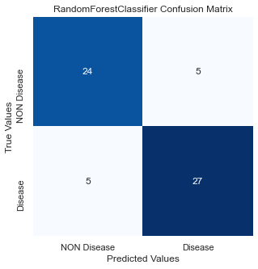

```
RandomForestClassifier Classification Report
============================================================
              precision    recall  f1-score   support

 Non Disease       0.83      0.83      0.83        29
     Disease       0.84      0.84      0.84        32

    accuracy                           0.84        61
   macro avg       0.84      0.84      0.84        61
weighted avg       0.84      0.84      0.84        61
```

```python
from sklearn.ensemble import RandomForestClassifier

# call model
clf = Model(model=RandomForestClassifier(), X=X, y=y)

clf.crossValScore(cv=5)

clf.confusionMatrix()

clf.classificationReport()
```

```
SVC Model Trained..
SVC
============================================================
Model accuracy : 0.773
Model precision : 0.812
Model recall : 0.781
Model roc_auc : 0.870
```

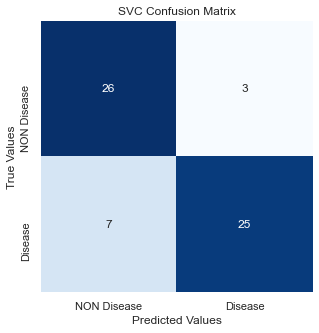

```
SVC Classification Report
============================================================
              precision    recall  f1-score   support

 Non Disease       0.79      0.90      0.84        29
     Disease       0.89      0.78      0.83        32

    accuracy                           0.84        61
   macro avg       0.84      0.84      0.84        61
weighted avg       0.84      0.84      0.84        61
```

```python
from sklearn.svm import SVC

svm = Model(model=SVC(C=5, probability=True), X=X, y=y)

svm.crossValScore(cv=10)

svm.confusionMatrix()

svm.classificationReport()
```

```
LogisticRegression Model Trained..
LogisticRegression
============================================================
Model accuracy : 0.814
Model precision : 0.822
Model recall : 0.849
Model roc_auc : 0.886
```

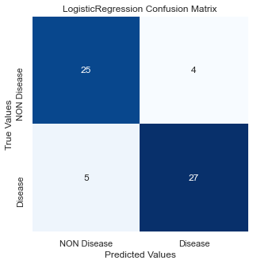

```
LogisticRegression Classification Report
============================================================
              precision    recall  f1-score   support

 Non Disease       0.83      0.86      0.85        29
     Disease       0.87      0.84      0.86        32

    accuracy                           0.85        61
   macro avg       0.85      0.85      0.85        61
weighted avg       0.85      0.85      0.85        61
```

```python
from sklearn.linear_model import LogisticRegression

lr = LogisticRegression()

lr = Model(model=lr, X=X, y=y)

lr.crossValScore()

lr.confusionMatrix()

lr.classificationReport()
```

```
KNeighborsClassifier Model Trained..
KNeighborsClassifier
============================================================
Model accuracy : 0.806
Model precision : 0.813
Model recall : 0.850
Model roc_auc : 0.869
```

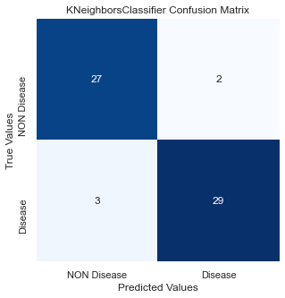

```
KNeighborsClassifier Classification Report
============================================================
              precision    recall  f1-score   support

 Non Disease       0.90      0.93      0.92        29
     Disease       0.94      0.91      0.92        32

    accuracy                           0.92        61
   macro avg       0.92      0.92      0.92        61
weighted avg       0.92      0.92      0.92        61
```

```python
from sklearn.neighbors import KNeighborsClassifier

knn = Model(model=KNeighborsClassifier(n_neighbors=5), X=X, y=y)

knn.crossValScore(cv=5)

knn.confusionMatrix()

knn.classificationReport()
```

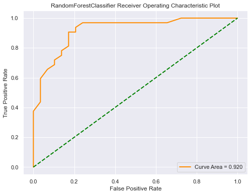

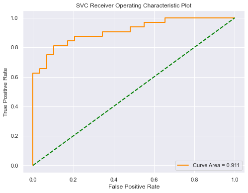

```python
models = [clf, svm, lr, knn]
for model in models[:2]:
    model.rocCurve()
```

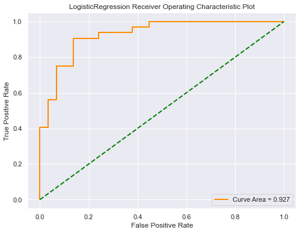

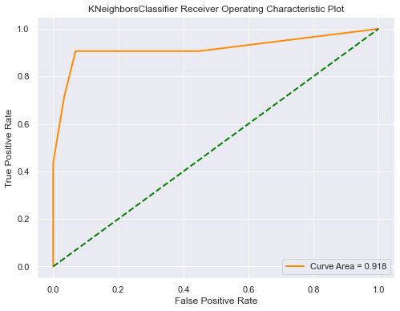

```python
for model in models[2:]:
    model.rocCurve()
```

```python
models = [clf, svm, lr, knn]
names = []
accs = []
for model in models:
    accs.append(model.accuracy());
    names.append(model.model_str());
```

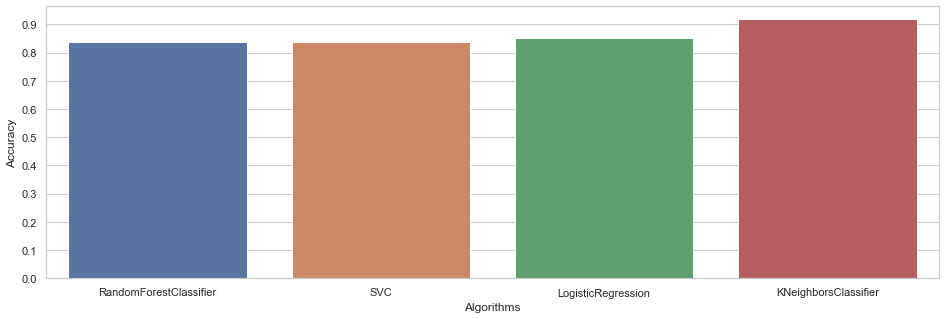

```python
sns.set_style("whitegrid")
plt.figure(figsize=(16,5))
plt.yticks(np.arange(0,1.2,0.1))
plt.ylabel("Accuracy")
plt.xlabel("Algorithms")
sns.barplot(x=names, y=accs)
plt.savefig('models_accuracy.png')
plt.show()
```

According to the accuracy metric we have a winner here.

Note that: ACCURACY metric isn't the best metric in such situation, you can test other metrics for your certain.